# SYDE 556

# Assignment 1: Representations in Populations of Neurons

**Author:** *Jonathan Johnston*

**Course Instructor:** *Professor C. Eliasmith*

This assignment is an introduction into the basic behaviours of a set of neuron models. It describes some ways in which neuron populations may hold a representation of a given stimuli, as well as the error associated in representation.

The assignment corresponds to the document hosted at:

http://nbviewer.ipython.org/github/celiasmith/syde556/blob/master/Assignment%201.ipynb

## Section 1: Representation of Scalars

### 1.1 Basic Encoding and Decoding

In this section we define a rectified linear neuron model which will be used in subsequent parts of the assignment.

#### Part A

In this section we generate a set of random rectified linear neurons and plot them together.

```
{'alpha': 302.7486688044811, 'x_int': -0.5863175132062743, 'max_fire_rate': 125.24182218452778, 'j_bias': -177.50684661995334, 'encoder': -1}
```

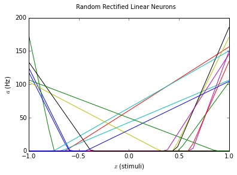

#### Part B

In this section we find the optimal decoders for the generated neuron population.

```
Decoders:  [  1.27868286e-02   1.06104688e-03   1.47608793e-02  -1.92313556e-03
   7.89726219e-04  -1.45547825e-03   5.45000057e-04  -1.74013763e-02
   7.56167497e-14  -7.56554289e-04  -8.60648740e-03   2.28423639e-03
  -3.54890845e-03  -4.45060577e-05  -1.57825721e-04  -3.29282909e-03]
```

#### Part C

In this section, we decode firing rates into an approximation of the stimuli, which describes how the neurons represent the stimuli.

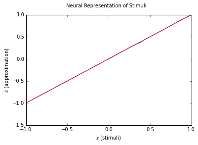

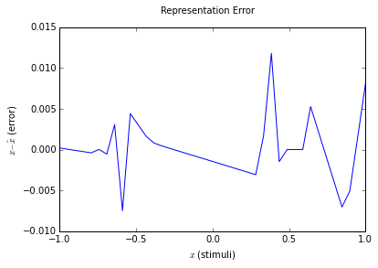

```
Root Mean Squared Error (RMSE):  0.00343041803281
```

#### Part D

We decode under Gaussian noise proportional to the highest firing rate in the population.

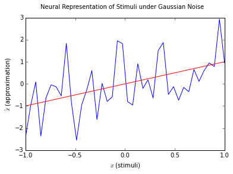

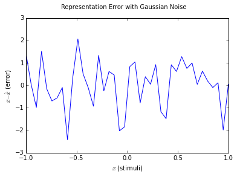

```
Root Mean Squared Error under Gaussian Noise (RMSE):  1.03866767172
```

#### Part E

We recompute optimal decoders to take Gaussian noise into account.

```
Decoders under noise:  [ -2.91049538e-04  -2.64506519e-04   1.77250765e-03   1.09927847e-03
  -5.32878835e-05   3.71258339e-04   2.35937776e-04  -2.73721939e-04
   2.29395810e-05  -8.18836806e-05   1.28951530e-03   8.78549601e-04
  -3.55041961e-03  -6.79393517e-04   1.75979242e-03  -3.99152543e-03]
```

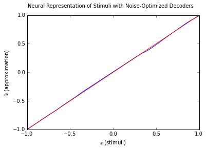

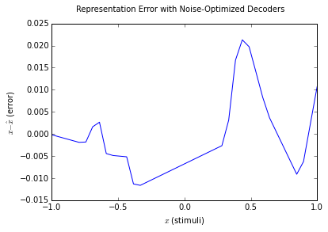

```
Root Mean Squared Error with Noise-Optimized Decoders (RMSE):  0.00822719565029
```

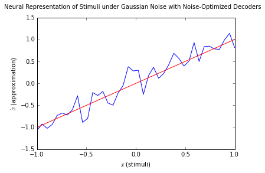

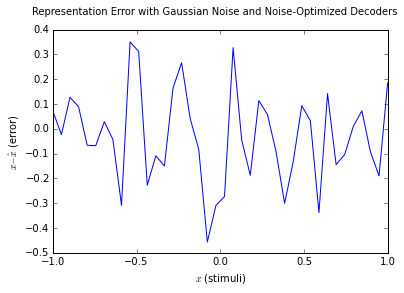

```
Root Mean Squared Error under Gaussian Noise with Noise-Optimized Decoders (RMSE):  0.191346117467
```

#### Part F

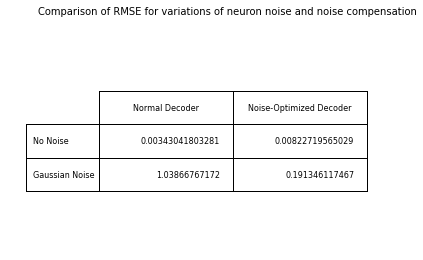

### 1.2 Exploring Sources of Error

#### Part A and B

Here, we explore various error associated with various numbers of neurons.

```
Number of neurons [4, 8, 16, 32, 64, 128, 256]
```

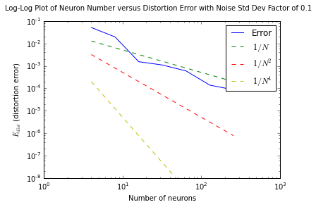

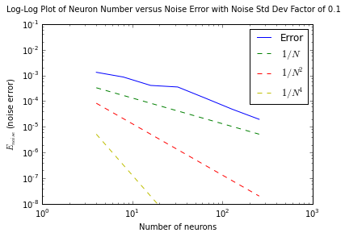

```
Standard deviation factor of noise:  0.1
Error due to distortion:  [0.050942052924142278, 0.019439286294447734, 0.001528475937545353, 0.001091817007590984, 0.00059242112947441522, 0.00013845854962465107, 8.5941674086568312e-05]
Error due to noise:  [0.0013214195808122174, 0.00086141188679938715, 0.0004073501777461629, 0.00035374787811917575, 0.00013239431064105637, 4.8658401036988124e-05, 1.9561235139807447e-05]
```

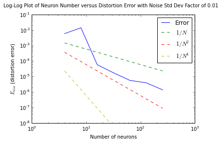

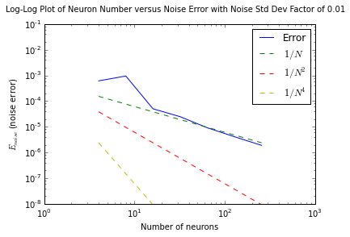

```
Standard deviation factor of noise:  0.01
Error due to distortion:  [0.0058457465175674132, 0.013862739790768162, 5.7198260071924361e-05, 1.7143192558348405e-05, 5.6033770727600294e-06, 3.9238876499237345e-06, 1.3716717459973318e-06]
Error due to noise:  [0.00061203493346832707, 0.00094586151683884493, 5.0210594997922611e-05, 2.4777773080958123e-05, 9.1715550033233666e-06, 4.1125826549161468e-06, 1.8971277263802441e-06]
```

### 1.3 Leaky Integrate-and-Fire Neurons

#### Part A

Here we define a leaky integrate-and-fire neuron model.

```
{'alpha': 5.4086794376427898, 'x_int': 0.056894806132190556, 'tau_rc': 0.02, 'max_fire_rate': 179.20017674373074, 'tau_ref': 0.002, 'j_bias': 0.69227423196414806, 'encoder': 1}
```

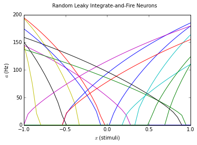

#### Part B

Now we find the error due to noise.

```
Noise-optimized decoders:  [ 0.00160684  0.00027159 -0.0011432   0.00080915 -0.00120326 -0.00018716
 -0.00070381  0.00076376 -0.00086382  0.00055182  0.00059563  0.00101251
 -0.00034474 -0.00099616 -0.00079977  0.00052491]
```

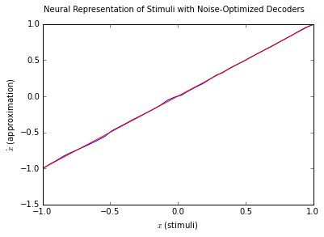

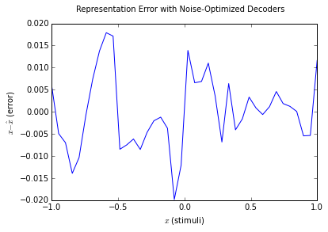

```
Root Mean Squared Error with Noise-Optimized Decoders (RMSE):  0.00843094365499
```

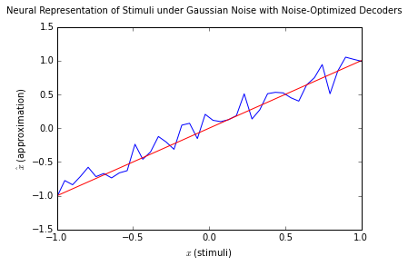

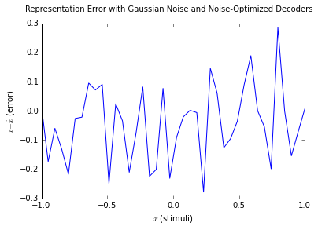

```
Root Mean Squared Error under Gaussian Noise with Noise-Optimized Decoders (RMSE):  0.13471809092
```

## Section 2: Representation of Vectors

### 2.1 Vector Tuning Curves

#### Part A

We now bring the previous LIF model into two dimensions. It is worth noting that the plot is representing the entire grid of -1 to 1 on both the x and y axes. This means that the tuning curve appears as if it hits a higher frequency than is defined in its max firing rate. This is not the case, however, because the activity should stop at the unit circle defined around the origin (0,0).

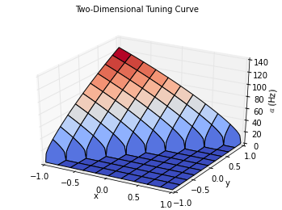

#### Part B

In this section we use a set of points distributed evenly around the unit circle as stimuli to find the corresponding firing rates.

We also fit a cosine on the resulting curve. The cosine is a good fit because it approximates the nature of taking values of a sort of exponential function along a circular curve. Where it fails is in its periodicity. The tuning curve is only active in a defined region, and is zero elsewhere, whereas the cosine curve is periodic and has no discontinuities. The cosine is also not ideal because the function being approximated is exponential, and therefore many cosines would be necessary to approximate it perfectly.

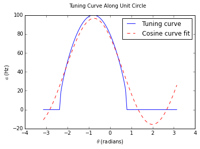

### 2.2 Vector Representation

#### Part A

We generate a set of 100 random, uniformly distributed unit vectors as encoders and plot them.

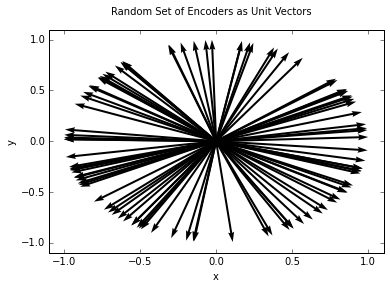

#### Part B

The encoders all lie on the unit circle, and therefore have magnitude one. The magnitudes of the decoders, on the other hand, are extremely small in comparison. It follows reason that in representing a stimuli that will have at maximum a value of one, a weighted sum of the firing rates of a large number of neurons will result in each neuron's weight being extremely small. In addition, the angles of the decoder vectors are distributed somewhat evenly, as are the angles of the encoder vectors.

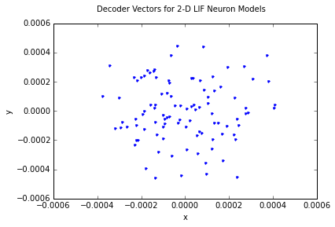

#### Part C

Now we look at the stimuli as it is represented by the neuron population, and compare with the actual stimuli. As we can see, the accuracy of using the decoders to represent the stimuli is very good.

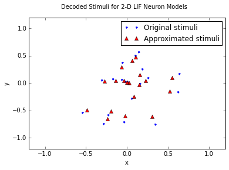

```
RMSE:  0.0580468379652
```

#### Part D

Using the encoders as decoders, we repeat Part C normally. As well, we repeat C and D whilst ignoring the magnitude of the representation and stimuli vectors.

As we can see, without normalizing the result, the error corresponding with the use of encoders as decoders is extremely high. Using the decoders themselves results in a much lower error.

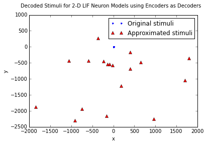

```
RMSE:  1031.52758096
RMSE, normalizing vectors:  17.0257207443
RMSE for use of encoder as decoder, normalizing vectors:  0.346794253054
```